# Bernoulli regression model

Case study: Space shuttle Challenger disaster

Georgios P. Karagiannis @ MATH3341/4031 Bayesian statistics III/IV (practical implementation)

[Back to README](https://github.com/georgios-stats/Bayesian_Statistics_Michaelmas_2021/tree/main/Computer_practical#aim)

```r
rm(list=ls())
```

*Aim*

Students will become able to:

- produce Monte Carlo approximations of posterior quantities required for Bayesian analysis with the RJAGS R package
- implement Bayesian posterior analysis in R with RJAGS package

Students are not required to learn by heart any of the concepts discussed

*Reading material*

*The material about RJAGS package is not examinable material, but it is provided for the interested student. It contains references that students can follow if they want to further explore the concepts introdced.*

- Lecture notes:
  - the examples and exercises related to the Bernoulli model with conjugate prior
- Application (optional):
  - [Dalal, S. R., Fowlkes, E. B., & Hoadley, B. (1989). Risk analysis of the space shuttle: Pre-Challenger prediction of failure. Journal of the American Statistical Association, 84(408), 945-957.](https://www.tandfonline.com/doi/abs/10.1080/01621459.1989.10478858)
- References for *rjags*:
  - [JAGS homepage](http://mcmc-jags.sourceforge.net)
  - [JAGS R CRAN Repository](https://cran.r-project.org/web/packages/rjags/index.html)
  - [JAGS Reference Manual](https://cran.r-project.org/web/packages/rjags/rjags.pdf)
  - [JAGS user manual](https://sourceforge.net/projects/mcmc-jags/files/Manuals/4.x/jags_user_manual.pdf/download)
- Reference for *R*:
  - [Cheat sheet with basic commands](https://www.rstudio.com/wp-content/uploads/2016/10/r-cheat-sheet-3.pdf)
- Reference of *rmarkdown* (optional):
  - [R Markdown cheatsheet](https://www.rstudio.com/wp-content/uploads/2016/03/rmarkdown-cheatsheet-2.0.pdf)
  - [R Markdown Reference Guide](http://442r58kc8ke1y38f62ssb208-wpengine.netdna-ssl.com/wp-content/uploads/2015/03/rmarkdown-reference.pdf)
  - [knitr options](https://yihui.name/knitr/options)
- Reference for *Latex* (optional):
  - [Latex Cheat Sheet](https://wch.github.io/latexsheet/latexsheet-a4.pdf)

*New software*

- R package `rjags` functions:
  - `jags.model{rjags}`
  - `jags.samples{rjags}`
  - `update{rjags}`

# Application: Challenger O-ring

On January 28, 1986, a routine launch was anticipated for the Challenger space shuttle. Seventy-three seconds into the flight, disaster happened: the shuttle broke apart, killing all seven crew members on board. [Here is the video](https://youtu.be/fSTrmJtHLFU?t=99).

The Rogers Commission report on the space shuttle Challenger accident concluded that the accident was caused by a combustion gas leak through a joint in one of the booster rockets, which was sealed by a device called an O-ring. The Challenger accident was caused by gas leak through the 6 O-ring joints of the shuttle.

The commission further concluded that 0-rings do not seal properly at low temperatures.

[Dalal, Fowlkes and Hoadley (1989)](https://www.jstor.org/stable/pdf/2290069.pdf) looked at the number of distressed O-rings (among the 6) for 23 previous shuttle flights, and the data-set is provided below. In the table below presents data from the 23 preaccident launches of the space shuttle is used to predict 0-ring performance under the Challenger launch conditions and relate it to the catastrophic failure of the shuttle. The the data-set is provided below, where in column *Defective.O.rings*, (1) stands for presence of at least one distressed O-ring, and (0) stands for absence of any distressed O-ring; while the rest columns are self explained.

```r
# Load R package for printing
library(knitr)
library(kableExtra)
```

```r
# load the data
#mydata <- read.csv("./challenger_data.csv")
mydata <- read.csv("https://raw.githubusercontent.com/georgios-stats/Bayesian_Statistics_Michaelmas_2021/main/Computer_practical/Bernoulli_regression_model/challenger_data.csv")
# print data
## (that's a sophisticated command with fancy output, feel free to ignore it)
kable(mydata)%>%
  kable_styling(bootstrap_options = c("striped", "hover"))
```

| Flight | Date | Temperature | Defective.O.rings | Leak.check.pressure |
| --- | --- | --- | --- | --- |
| 1 | 04/12/1981 | 66 | 0 | 50 |
| 2 | 11/12/1981 | 70 | 1 | 50 |
| 3 | 3/22/82 | 69 | 0 | 50 |
| 5 | 01/11/1982 | 68 | 0 | 50 |
| 6 | 04/04/1983 | 67 | 0 | 100 |
| 7 | 6/18/83 | 72 | 0 | 100 |
| 8 | 8/30/83 | 73 | 0 | 200 |
| 9 | 11/28/83 | 70 | 0 | 200 |
| 41-B | 02/03/1984 | 57 | 1 | 200 |
| 41-C | 04/06/1984 | 63 | 1 | 200 |
| 41-D | 8/30/84 | 70 | 1 | 200 |
| 41-G | 10/05/1984 | 78 | 0 | 200 |
| 51-A | 11/08/1984 | 67 | 0 | 200 |
| 51-C | 1/24/85 | 53 | 1 | 200 |
| 51-D | 04/12/1985 | 67 | 0 | 200 |
| 51-B | 4/29/85 | 75 | 0 | 200 |
| 51-G | 6/17/85 | 70 | 0 | 200 |
| 51-F | 7/29/85 | 81 | 0 | 200 |
| 51-I | 8/27/85 | 76 | 0 | 200 |
| 51-J | 10/03/1985 | 79 | 0 | 200 |
| 61-A | 10/30/85 | 75 | 1 | 200 |
| 61-B | 11/26/85 | 76 | 0 | 200 |
| 61-C | 01/12/1986 | 58 | 1 | 200 |
| 61-I | 1/28/86 | 31 | Challenger Accident | 200 |

On the night of January 27, 1986, the night before the space shuttle Challenger accident, there was a three-hour teleconference among people at Morton Thiokol, Marshall Space Flight Center, and Kennedy Space Center. The discussion focused on the forecast of a 31F temperature for launch time the next morning, and the effect of low temperature on 0-ring performance.

We are interested in finding:

- what is the limiting frequency of occuring a defective O-ring when the temperature at the platform is 31F (namely the one on the day of the accident 1/28/86 of flight 61-I)
- what are the odds of at least one defective O-rings under the conditions above?
- what is the probability that a damaged O-ring would occur in the $24$th flight (date *1/28/86*)?

To answer the above we perform Bayesian analysis based on the observed data-set on the dates from *04/12/1981* to *01/12/1986*, and the variables *Damage.Incident* and *Temperature*. So ignore the variable *Leak.check.pressure*.

# Model specification & posterior sampling

Let $y_{i}$ denote the presence of a defective O-ring in the $i$th flight ($0$ for absence, and $1$ for presence).

Let $t_{i}$ denote the temperature (in F) in the platform before the $i$th flight.

**Regarding the statistical model**, we assume that $y_{i}$ can be modeled as observations generated independently from a Bernoulli distribution with with parameter $p_{i}$. Here, $p_{i}$ denotes the relative frequency of defective O-rings at flight $i$. We drop the assumption of homogeneity in the parameters!!!

As we are interesting in studing the relation of the outcome variable $y$: ‘presence of a defective O-ring’ with the input variable $t$: ‘temperature’. Then, given the statistical model specified, it is reasonable to link the two variables through the only parameter $p$ of the sampling distribution.

A reasonable link would be
$$\begin{align*}
p(t;\beta)
=&
\frac{\exp(\beta_0+\beta_1 t)}{1+\exp(\beta_0+\beta_1 t)} \
\iff \
\log(\frac{p(t;\beta)}{1-p(t;\beta)})
=
\beta_0+\beta_1 t
\end{align*}$$
where $\beta=(\beta_0,\beta_1)$ because:

- it provides a bijective transformation between spaces of $p:=p(t;\beta)\in[0,1]$ and $\beta_0+\beta_1 t \in \mathbb{R}$.
- it also gives a simple link between the odds $\frac{p(t;\beta)}{1-p(t;\beta)}$ and the input variable $t$.

Hmm…., you could use any other function; like the CDF of the Normal, Student’s T, Laptace distr., etc…

**Regargind the prior model**, we assign a Normal prior distribution, with mean hyper-parameter $b_0$ and variance hyper-parameter $B_0$, on the unknown parameter $\beta$ to account for the uncertainty about it.

Hmmmm… we could use other priors too … I just picked one …

**The Bayesian hierarchical model** under consideration is:
$$\begin{cases}
y_{i}|\beta\sim & \text{Bernoulli}(p(t_i;\beta)),\quad\text{for, }i=1,...,n\\
& \\
p(t;\beta)
=&
\frac{\exp(\beta_0+\beta_1 t)}{1+\exp(\beta_0+\beta_1 t)} \\
& \\
\beta\sim & \text{N}(b_0,B_0) ,
\end{cases}$$
with hyper-parameter values
$$b_0=\begin{pmatrix}0.0\\ 0.0 \end{pmatrix} \text{, and } B_0=\begin{pmatrix}100.0 & 0.0\\ 0.0 &100.0\end{pmatrix}$$

# 1 Task

We write the JAGS program implementing the hierarchical model above, in order to generate a sample of size $N=100000$ from the posterior distribution
$$\beta^{(j)}\sim\pi(\beta|y_{1:n})\ ,\ \ j=1,...,N.$$
.

### … your answer

We actually extend what we did in the handout BernoulliModel.Rmd.

*step 1*

Load the library

```r
# Load rjags
library("rjags")
```

*step 2*

Create an input script, for rjags, containing the Bayesian hierarchical model

```r
# Input parameters  : n, y, b_0, invB_0
# output parameters : beta
hierarhicalmodel <- "

  model {

    # sampling distribution

    for ( i in 1 : n ) {

      p[ i ] <- exp(inprod(X[i,],beta)) / (1+exp(inprod(X[i,],beta)))

      y[ i ] ~ dbern( p[ i ] )
    }

    # a priori distribution

    beta ~ dmnorm( b_0 , invB_0 )

  }

"
```

*step 3*

Create an input list, for jags, containing the data and fixed parameters of the model

```r
y_obs <- mydata[ -nrow(mydata) , 4 ] # exclude the last row, and use only the 4th column
y_obs <- as.numeric(y_obs==1)        # make it numeric

n_obs <- length( y_obs )

X_obs <- cbind( rep(1,n_obs),
                as.numeric(mydata[ -nrow(mydata),3]) )

d = dim(X_obs)[2]  #

b_0 <- rep( 0.0 , d )  # prior hyper-parameter

B_0 <- diag( rep( 100 , d ) )

invB_0 <- solve( B_0 )


data.bayes <- list(y = y_obs,
                    n = n_obs,
                   X = X_obs,
                    b_0 = b_0,
                   invB_0 = invB_0)
```

*step 4*

Create an input list, for jags, containing the data and fixed parameters of the model

```r
model.smpl <- jags.model( file = textConnection(hierarhicalmodel),
                          data = data.bayes)
```

*step 5*

```r
adapt(object = model.smpl,
      n.iter = 10^5)
```

*step 6*

Use

- `jags.samples{rjags}`
  - `=jags.samples(model=, variable.names=, n.iter=, thin=)`

We can ask function `jags.samples` to generate a sample sequence of $N_{total}$ values (in total), but return, as a sample, only every $N_{thin}$-th sample value from that sequence. This can be performed. This means that the function returns a sample of size $N=N_{total}/N_{thin}$. The reason will become clear soon.

We need to pay attention on two flaqs:

- the `variable.names`: it specifies the names of the random variables correspondign to the posterior samples I am interested in generating
- the `n.iter`: the size of the total sample sequence generated.
- the `thin`: the thining interval (use `thin=1` for now). It makes the algorithm to return only every `thin`-th sample value from the total sample sequence generated. **Ask your instructor about it**.

```r
N = 10^5      # the size of the sample we ll gona get
n.thin = 10^2     # the thining (improving) the sample quality
n.iter = N * n.thin # the number of the total iterations performed
output = jags.samples( model = model.smpl,          # the model
                       variable.names = c("beta"),    # names of variables to be sampled
                       n.iter = n.iter,               # size of sample
                       thin = n.thin,
                       )
save.image(file="BernoulliRegressionModel.RData")
```

Check the names of the variables sampled

- use `names {base}`

```r
names(output)
```

```
## [1] "beta"
```

Check the dimensions of each of the variables sampled

- use `dim {base}`

```r
dim( output$beta )
```

```
##           iteration     chain
##         2    100000         1
```

```r
# the first dimension is the numbers of columns of the variable
# the second dimention is the size of the sample drawn
# the thirs dimention is the number of the sub-samples drawn (in our case it is just 1)
```

Copy the sample of each variable in a vector with a more friendly name…

```r
beta.smpl <-output$beta
```

# 2 Task

Print the trace plot of the sample drawn from the posterior distribution
$$\beta^{(j)}\sim\pi(\beta|y_{1:n})\ \ j=1,...,N$$

Use functions:

- `plot {graphics}`.

A glimpse into Term 2 Bayesian statistics:

- A good quality sample for the purposes of Monte Carlo integration is the one whose trace plot looks completely uncorelated.
  - e.g. like the independence assumption in the siple linear regression in SC2.
- To improve the quality of the sample, you can go back to the sampling stem and play with the flaq values of `n.iter` and `thin` in `jags.samples{rjags}`.

### … your answer

```r
# extract the sample from the jags object
beta.smpl <- output$beta
```

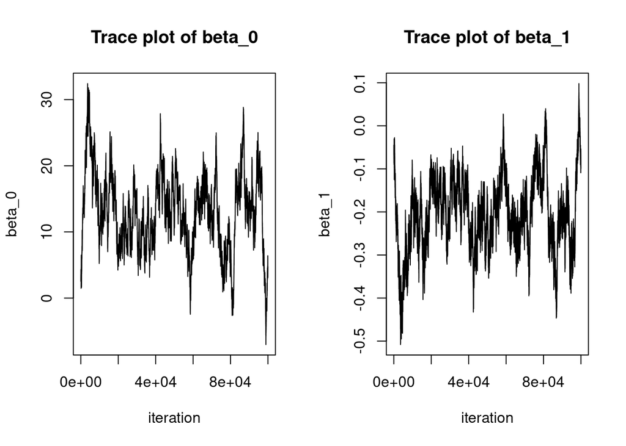

```r
# extract the sample, and copy it to smple
beta.smpl <- output$beta

# draw the trace plots

par(mfrow=c(1,2))
z <- beta.smpl[1,,]
plot(z,
     type = "l",
     main = "Trace plot of beta_0",
     xlab = "iteration",
     ylab ="beta_0"
     )
z <- beta.smpl[2,,]
plot(z,
     type = "l",
     main = "Trace plot of beta_1",
     xlab = "iteration",
     ylab ="beta_1"
     )
```

# 3 Parameteric posterior analysis of $\beta_{1}$

Regarding the parameter $\beta_{1}$, we can calculate that
$$\begin{align*}
\beta_{1}
&=
\frac{\log\left(\frac{p(t')}{1-p(t')}\right)-\log\left(\frac{p(t;\beta)}{1-p(t;\beta)}\right)}
{t'-t}
\end{align*}$$
by properly rearanging the the link function $\log(\frac{p}{1-p})=\beta_0+\beta_1 t$ considered.

Hence the parameter $\beta_1$ can be interpreted as:

- the rate of change of the odds of a defective O-ring (in log scale) with respect to the temperature
  - this is can be seen as $t'-t\rightarrow 0$
- the change of the odds of a defective O-ring (in log scale) if the temperature increase for $1$ unit
  - this can be seen as $t'-t = 1$

So:

- $\beta_1>0$ means that $t\uparrow\implies p\uparrow$ and $t\downarrow \implies p\downarrow$
- $\beta_1<0$ means that $t\downarrow\implies p\uparrow$ and $t\uparrow\implies p\downarrow$

## 3.1 Task

Compute the MC approximation of the posterior probability density function, and the cumulative distribution function of $\beta_1$ as

### … your answer

The MC approximate of the posterior PDF and CDF of $\beta_{1}$ are

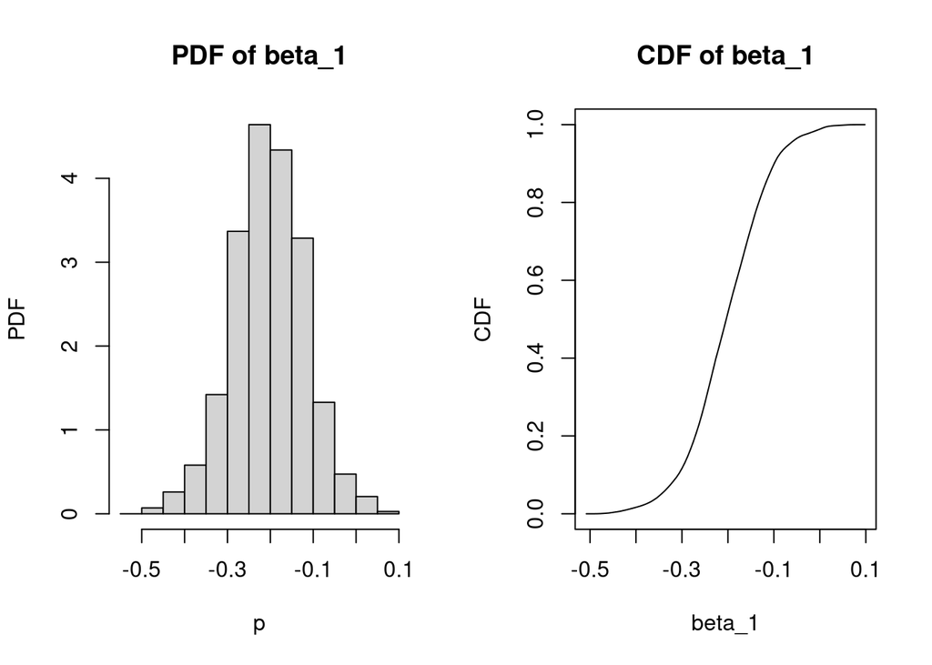

```r
par(mfrow=c(1,2))
## extract the sample, and copy it to smple
beta.smpl <- output$beta
z <- beta.smpl[2,,]
## draw
hist(z,
     probability = TRUE,
     main = "PDF of beta_1",
     xlab = "p",
     ylab = "PDF")
## draw
x_plot <- seq( from = min(z), to = max(z), length.out = 100)
y_plot <- rep(NaN, 100)
for (i in 1:100) y_plot[i] <- mean(z<=x_plot[i])
plot(x_plot,
     y_plot,
     type = "l",
     main = "CDF of beta_1",
     xlab = "beta_1",
     ylab = "CDF")
```

We notice that the posterior PDF is unimodal and that almost all the mass is above negative values of $\beta$.

## 3.2 Task

Compute the MC approximate of the posterior expected value of $\beta_1$ as
$$\text{E}_{\pi}(\beta_1|y_{1:n})
\approx
\frac{1}{N}\sum_{j=1}^{N}\beta_1^{(j)}$$

### … your answer

The MC approximate of the $\text{E}_{\pi}(\beta_1|y_{1:n})$ is

```r
## extract the sample, and copy it to smple
beta.smpl <- output$beta
z <- beta.smpl[2,,]
beta_1.mc <- mean(z)
beta_1.mc
```

```
## [1] -0.2034238
```

## 3.3 Task

Compute the MC approximate of the posterior standard deviation of $\beta_1$ as
$$\begin{align*}
\text{SD}_{\pi}(\beta_1|y_{1:n})
=&\sqrt{\text{E}_{\pi}(\beta_1^{2}|y_{1:n})-(\text{E}_{\pi}(\beta_1|y_{1:n}))^{2}}\\
\approx&
\sqrt{\frac{1}{N}\sum_{j=1}^{N}\left(\beta_1^{(j)}\right)^{2}-\left(\frac{1}{N}\sum_{j=1}^{N}\beta_1^{(j)}\right)^{2}}\\
=&s_{\beta_1}^{2}
\end{align*}$$

### … your answer

The MC approximate of the $\text{SD}_{\pi}(\beta_1|y_{1:n})$ is

```r
## extract the sample, and copy it to smple
beta.smpl <- output$beta
z <- beta.smpl[2,,]
sdbeta_1.mc <- sd(z)
sdbeta_1.mc
```

```
## [1] 0.08507221
```

## 3.4 Task

Compute the MC approximate of the posterior probability that the rate $\beta_1$ under consideration is negative;
$$\begin{align*}
\text{Pr}_\pi(\beta_1<0|y_{1:n})
=&
\text{E}_\pi(\text{1}(\beta_1<0)|y_{1:n})\\
\approx&
\frac{1}{N}\sum_{j=1}^{N}\text{1}(\beta_1^{(j)}<0)
\end{align*}$$

### … your answer

The MC approximate of $\text{Pr}_\pi(\beta_1<0|y_{1:n})$ is

```r
## extract the sample, and copy it to smple
beta.smpl <- output$beta
z <- beta.smpl[2,,]
pr.mc <- mean(z<0)
pr.mc
```

```
## [1] 0.98837
```

…which means that the odds of the occurance of a failed O-ring increase as the temperature decrease.

## 3.5 Task

Compute the MC approximate posterior $95$% credible interval (equal tail) of $\beta_1$,
$$[
Q_{0.025}(\beta_1|y_{1:n})\ ,\ Q_{0.975}(\beta_1|y_{1:n})
]$$
where
$$Q_{\alpha}(\beta_1|y_{1:n}) = F_{\beta_1}^{-1}(\alpha|y_{1:n})$$
is the $\alpha$-th quantile of the posterior distribution of $\beta_1$

### … your answer

```r
beta.smpl <- output$beta
z <- beta.smpl[2,,]
CI.mc <- quantile(z, probs = c(0.025, 0.0975))
CI.mc
```

[output not shown]

I notice that zero $0$ is not included in the posterio CI of $\beta_1$. This is an informal indicator that the temperature may actually affect whether O-ring fails or not.

# 4 Posterior analysis of frequency parameter $p(t;\beta)$

Regarding the parameter $p(t;\beta)$ which is a function of the temperature $t$, we can calculate that
$$\begin{align*}
p(t;\beta)
&=
\frac{\exp(\beta_0+\beta_1 t)}{1+\exp(\beta_0+\beta_1 t)}
\end{align*}$$
by properly rearanging the the link function $\log(\frac{p}{1-p})=\beta_0+\beta_1 t$.

## 4.1 Task

Compute and ploit MC approximate of the $95$% equal length credible interval of the parameter $p(t;\beta)$ for themperature values $t\in(30,82)$.

and plot them against the temperature $t\in(30,82)$ in the same plot.

Can we infer anything about flight 61-I on 1/28/86.

### … your answer

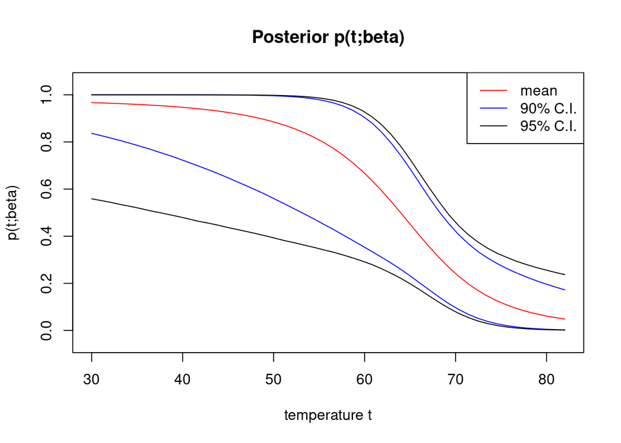

```r
# define the frequence parameter function p(t;beta)
freq_fun <-function(t, beta_0, beta_1) {
  freq <- exp(beta_0+beta_1*t) / (1+exp(beta_0+beta_1*t))
  return(freq)
}
#
# set the t values of the horizontal axis
n_plot = 50
t_plot <- seq(from = 30, to = 82, length.out = n_plot)
#
# for each value of the t_plot:
#
## create the vectors
p_Exp_mc <- rep(NaN, times = n_plot)
p_Lower_ci_95_mc <- rep(NaN, times = n_plot)
p_Upper_ci_95_mc <- rep(NaN, times = n_plot)
p_Lower_ci_90_mc <- rep(NaN, times = n_plot)
p_Upper_ci_90_mc <- rep(NaN, times = n_plot)
##
## extract the posterior sample
beta.smpl <- output$beta
beta.0.smple <- beta.smpl[1,,]
beta.1.smple <- beta.smpl[2,,]
##
## compute the expected value, and the quantiles
##
## compute the frequency parameter posterior
for (i in 1:n_plot) {
  ## compute the p posterior sample at temperature t_i
  t_i <- t_plot[i]
  z <- freq_fun(t_i, beta.0.smple,beta.1.smple)
  p_Exp_mc[i] <- mean(z)
  p_Lower_ci_95_mc[i] <- quantile(z,
                            probs = 0.025)
  p_Upper_ci_95_mc[i] <- quantile(z,
                            probs = 0.975)
  p_Lower_ci_90_mc[i] <- quantile(z,
                            probs = 0.05)
  p_Upper_ci_90_mc[i] <- quantile(z,
                            probs = 0.95)
}


plot(t_plot,
     p_Exp_mc,
     type = "l",
     col = "red",
     main = "Posterior p(t;beta)",
     xlab = "temperature t",
     ylab = "p(t;beta)",
     ylim = c(-0.05, 1.05)
     )
lines(t_plot,
     p_Upper_ci_90_mc,
     type = "l",
     col = "blue"
     )
lines(t_plot,
     p_Upper_ci_95_mc,
     type = "l",
     col = "black"
     )
lines(t_plot,
     p_Lower_ci_90_mc,
     type = "l",
     col = "blue"
     )
lines(t_plot,
     p_Lower_ci_95_mc,
     type = "l",
     col = "black"
     )
# Create a legend
legend("topright",
       legend=c("mean", "90% C.I.", "95% C.I."),
       lty = c(1,1,1),
       col=c("red","blue","black"))
```

# 5 Posterior predictive analysis of the outcome of flight 61-I on 1/28/86.

The predictive distribution mass function of $y_{n+1}|y_{1:n}$, is
$$\begin{align*}
f_{\pi}(y_{n+1}=c|y_{1:n};t)
=& \int f(y_{n+1}=c|\beta;t) \pi(\beta|y_{1:n}) \text{d}\beta, \ \ c\in \{0,1\} \\
&\\
=& \text{E}_\pi (f(y_{n+1}=c|\beta;t) |y_{1:n}), \ \ c\in \{0,1\} \\
&\\
=& \text{E}_\pi ( p(t;\beta)^{c} (1-p(t;\beta))^{1-c} |y_{1:n}), \ \ c\in \{0,1\} \\
&\\
=&
\begin{cases}
1- \text{E}_\pi ( p(t;\beta) |y_{1:n}) & \ \text{, c}=0 \\
&\\
\text{E}_\pi ( p(t;\beta)|y_{1:n}) & \ \text{, c}=1
\end{cases}
\end{align*}$$
at temperature $t$.

## 5.1 Task

Well, this means that we have already computed and ploted the MC approximation for the predictive distribution mass function of $y_{n+1}|y_{1:n}$ for at $t\in(30,82)$.

So now just …

Compute and plot the MC approximate of the predictive probability that a failed O-ring will occure at temperature $t=31$F, as
$$\begin{align*}
f(y_{n+1}=c|y_{1:n};t=31)
\approx&
\begin{cases}
1- \frac{1}{N}\sum_{j=1}^{N} p(t=31;\beta^{(j)}) & \ \text{, c}=0 \\
&\\
\frac{1}{N}\sum_{j=1}^{N} p(t=31;\beta^{(j)}) & \ \text{, c}=1
\end{cases}
\end{align*}$$

### … your answer

Well… we actually have already done this …

Let’s do the plot

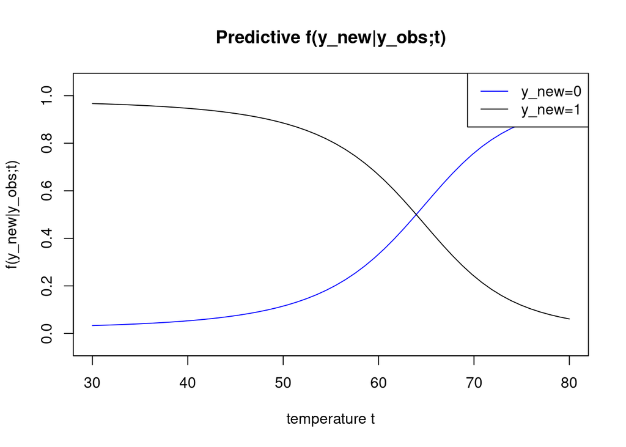

```r
# define the frequence parameter function p(t;beta)
freq_fun <-function(t, beta_0, beta_1) {
  freq <- exp(beta_0+beta_1*t) / (1+exp(beta_0+beta_1*t))
  return(freq)
}
#
# set the t values of the horizontal axis
n_plot = 50
t_plot <- seq(from = 30, to = 80, length.out = n_plot)
#
# for each value of the t_plot:
#
## create the vectors
p_Exp_mc <- rep(NaN, times = n_plot)
##
## extract the posterior sample
beta.smpl <- output$beta
beta.0.smple <- beta.smpl[1,,]
beta.1.smple <- beta.smpl[2,,]
##
## compute the expected value, and the quantiles
##
## compute the frequency parameter posterior
for (i in 1:n_plot) {
  ## compute the p posterior sample at temperature t_i
  t_i <- t_plot[i]
  z <- freq_fun(t_i, beta.0.smple,beta.1.smple)
  p_Exp_mc[i] <- mean(z)
}


plot(t_plot,
     1-p_Exp_mc,
     type = "l",
     col = "blue",
     main = "Predictive f(y_new|y_obs;t)",
     xlab = "temperature t",
     ylab = "f(y_new|y_obs;t)",
     ylim = c(-0.05, 1.05)
     )
lines(t_plot,
     p_Exp_mc,
     type = "l",
     col = "black",
)
# Create a legend
legend("topright",
       legend=c("y_new=0", "y_new=1"),
       lty = c(1,1),
       col=c("blue","black"))
```

Regarding the flight $61-I$ on date 1/28/86, when the temperature was $t=31$F, the predictive probability that at least one defective O-ring occurs is:

```r
# define the frequence parameter function p(t;beta)
freq_fun <-function(t, beta_0, beta_1) {
  freq <- exp(beta_0+beta_1*t) / (1+exp(beta_0+beta_1*t))
  return(freq)
}
#
# extract the posterior sample
#
beta.smpl <- output$beta
beta.0.smple <- beta.smpl[1,,]
beta.1.smple <- beta.smpl[2,,]
#
# compute the expected value, and the quantiles
#
t_new <- 31.0
z <- freq_fun(t_new, beta.0.smple,beta.1.smple)
p_Exp_mc_new <- mean(z)
p_Exp_mc_new
```

```
## [1] 0.9655926
```

# Conclusions and discussion.

## task

Now, it is January 27, 1986, and you take part in the 3-hour teleconference with people from Morton Thiokol, Marshall space flight center, and Kennedy space center.

The forcast says that tommorrow the temperature will be $31$F at lunch time. This is too frosty… and rare temperature for the area.

Would you cancel the lunch of the Space Shuttle 61-I on 1/28/86?

### … your answer

So yes, I would…

In fact: After the Challenger Space Shuttle 61-I accident on 1/28/86, a commission (the Rogers Commission) was appointed by President R. Reagan to find the cause. The Rogers Commission concluded that “A careful analysis of the flight history of 0-ring performance would have revealed the correlation of 0-ring damage in low temperature” (PC1, p. 148).

## Comments…

In the analysis above, we judged that the temperature affects the occurance of a defective O-ring. Actually, does this happen?

It would be interesting to actually infer if the occurance of a defective O-ring is affected by the leak check pressure as well. How could you possibly address this?

It would be interesting to actually infer if the effect of temperature on the occurance of a defective O-ring changes at different values of leak check pressure (aka if temperature and leak check pressure interact in a manner). How could you possibly address this?

If you have finished this handout, you can proceed to the next [Bernoulli regression model -variable selection].

### … your answer

Below try to address the task by creating R chunks, and running them, and adding comments to the document.